# R4DS_2E_exploratoryDataAnalysis

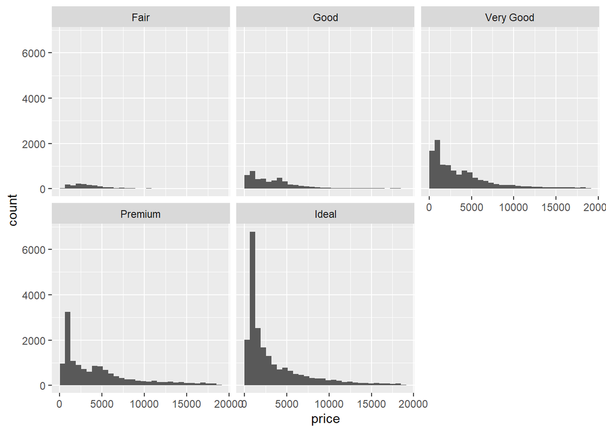

```r
# I heard violin plots are basically useless, but in this instance they are pretty good at showing how there are alot more "Ideal" diamonds at a price of around 1000-2000. This ties back into a lot of what we said previously that the best cut diamonds do not mean the most pricey.

ggplot(diamonds, aes(x = price)) +
  geom_histogram() +
  facet_wrap(~cut)
```

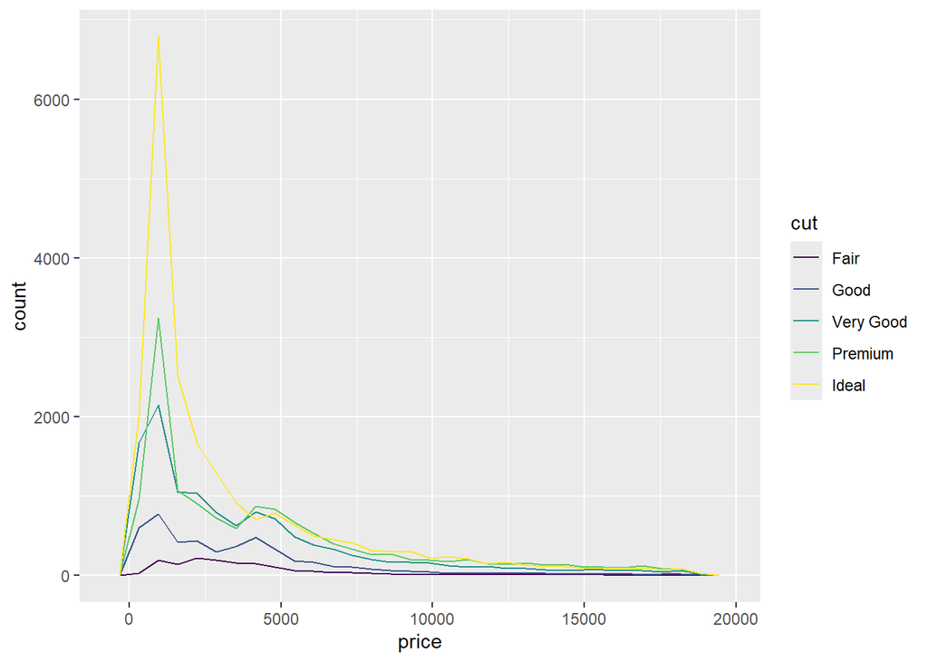

```r
# This is useful is we want a general overview of the count for each cut for each price. If we want to compare specific bins this is much harder to do.

ggplot(diamonds, aes(x = price)) +
  geom_freqpoly(aes(color = cut))
```

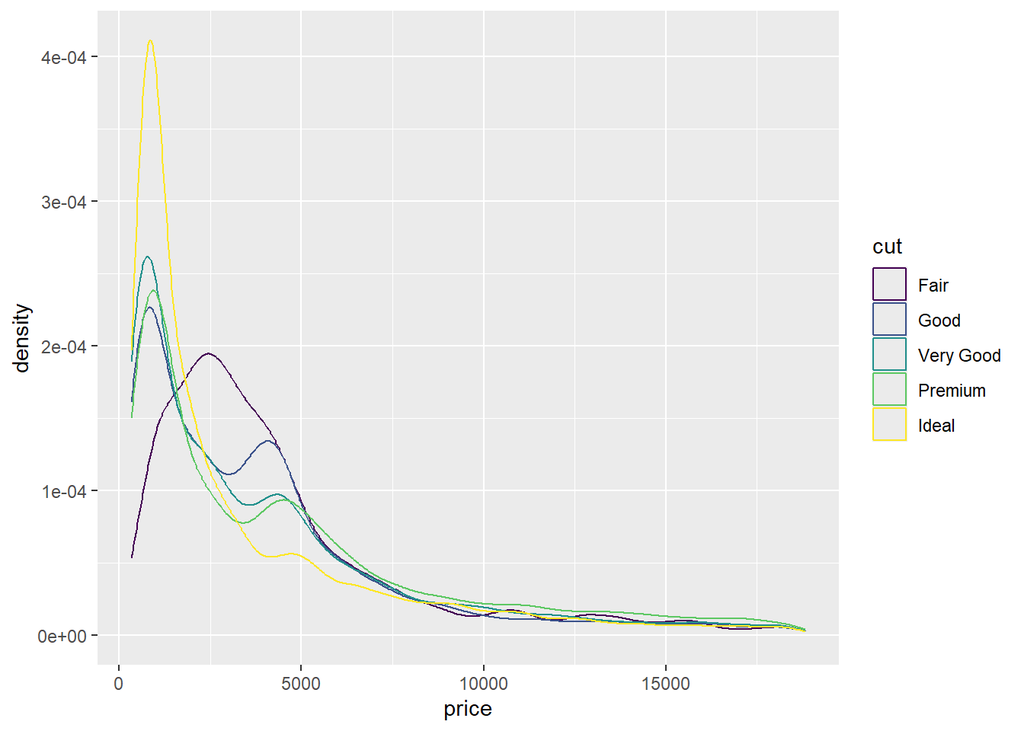

```r
# I would say this is a bit more useful than the above plot to get a general overview of the counts of different prices for different cuts. Again if the faceted variable has relatively similar counts it can obscure the relationship we want to show.

ggplot(diamonds, aes(x = price)) +
  geom_density(aes(color = cut))
```

```r
# This is really good if we have wildly different counts for different cuts. For example in the above two plots we see that if the total count for Fair diamonds is low. But since we now are using a density plot, we see some hidden information that was obscured previously. The majority of Fair diamonds are around the ~2500 price point which is higher than other cuts. This ties in to much of what we've been talking about. I think this is generally better than the violin plot.
```

6. If you have a small dataset, it’s sometimes useful to use geom_jitter() to avoid overplotting to more easily see the relationship between a continuous and categorical variable. The ggbeeswarm package provides a number of methods similar to geom_jitter(). List them and briefly describe what each one does.

Answer: Lets use the package prefix ‘ggbeeswarm::’ along with the autocomplete function by pressing TAB to see different geom functions ggbeeswarm provides

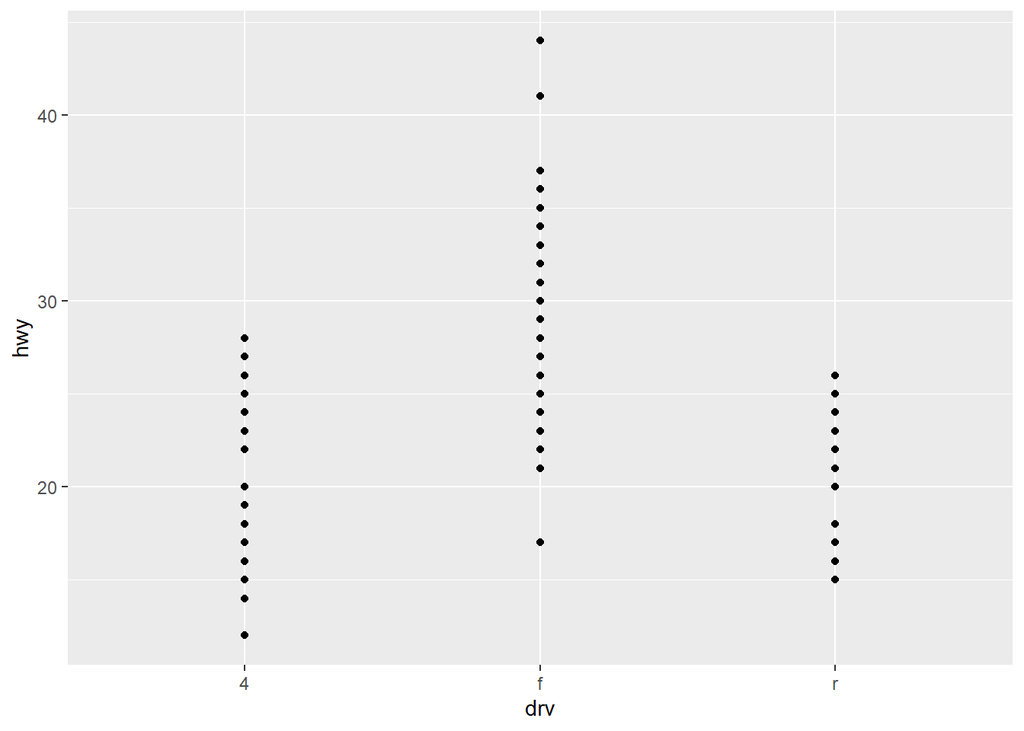

```r
# Lets use some examples to show the difference without using the beeswarm package:
ggplot(mpg, aes(drv, hwy)) +
  geom_point()
```

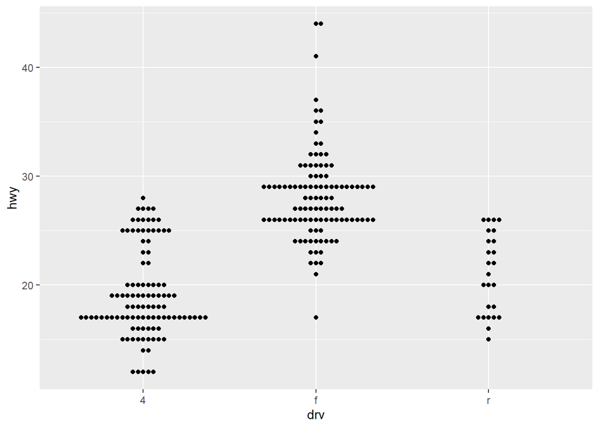

```r
ggplot(mpg, aes(drv, hwy)) +
  ggbeeswarm::geom_beeswarm()
```

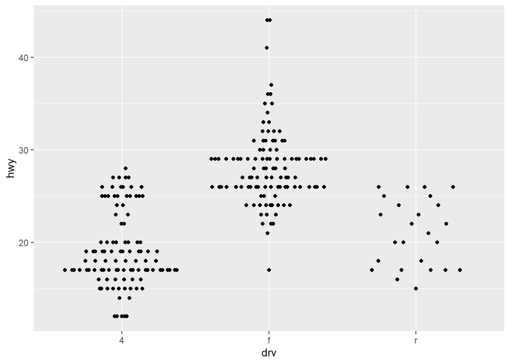

```r
# Simply offsets points so we can see where overlapping is

ggplot(mpg, aes(drv, hwy)) +
  ggbeeswarm::geom_quasirandom()
```

```r
# The offsetting is not by the same distance between each point, instead it is now a random distance.
```